# **Project: Exploratory Data Analysis of Loan Data from prosper**

## **By Kafaite Zahra Hussain**

## Preliminary Wrangling

The main objective of this project is to create a data visualization using Python that tells a story or highlights trends or patterns in a dataset.

This data set contains 113,937 loans with 81 variables on each loan, including loan amount, borrower rate (or interest rate), current loan status, borrower income, and many others

## **Gathering, Assessing and Cleaning data**

```python
# import all packages
import numpy as np
import pandas as pd
import matplotlib.pyplot as plt
import seaborn as sb
%matplotlib inline
```

```python
# load the raw dataset
df= pd.read_csv('prosperLoanData.csv')
df.sample(10)
```

|  | ListingKey | ListingNumber | ListingCreationDate | CreditGrade | Term | LoanStatus | ClosedDate | BorrowerAPR | BorrowerRate | LenderYield | EstimatedEffectiveYield | EstimatedLoss | EstimatedReturn | ProsperRating (numeric) | ProsperRating (Alpha) | ProsperScore | ListingCategory (numeric) | BorrowerState | Occupation | EmploymentStatus | EmploymentStatusDuration | IsBorrowerHomeowner | CurrentlyInGroup | GroupKey | DateCreditPulled | CreditScoreRangeLower | CreditScoreRangeUpper | FirstRecordedCreditLine | CurrentCreditLines | … |
| --- | --- | --- | --- | --- | --- | --- | --- | --- | --- | --- | --- | --- | --- | --- | --- | --- | --- | --- | --- | --- | --- | --- | --- | --- | --- | --- | --- | --- | --- | --- |
| 86599 | A21B3514986013248E1665C | 506568 | 2011-05-12 19:05:44.850000000 | NaN | 36 | Completed | 2012-09-03 00:00:00 | 0.35643 | 0.3199 | 0.3099 | 0.29170 | 0.2030 | 0.08870 | 1.0 | HR | 3.0 | 7 | NC | Military Enlisted | Employed | 184.0 | False | False | NaN | 2011-05-12 19:05:32 | 660.0 | 679.0 | 1992-09-01 00:00:00 | 6.0 | … |
| 53849 | F0693405387876860A1865A | 226939 | 2007-11-06 06:50:03.117000000 | A | 36 | Completed | 2010-10-18 00:00:00 | 0.12801 | 0.1210 | 0.1110 | NaN | NaN | NaN | NaN | NaN | NaN | 0 | MD | Civil Service | Full-time | 69.0 | True | False | NaN | 2007-11-06 06:49:07.867000000 | 720.0 | 739.0 | 1989-09-08 00:00:00 | 22.0 | … |
| 62292 | 54CC3566776882582474239 | 687515 | 2012-12-18 13:16:20.830000000 | NaN | 60 | Current | NaN | 0.27462 | 0.2489 | 0.2389 | 0.22060 | 0.0925 | 0.12810 | 3.0 | D | 6.0 | 15 | AL | Other | Other | 119.0 | False | False | NaN | 2012-12-18 13:16:18 | 740.0 | 759.0 | 2002-03-13 00:00:00 | 13.0 | … |
| 92053 | 5F6835893854935727A2D99 | 906647 | 2013-09-14 10:05:21.247000000 | NaN | 36 | Current | NaN | 0.33215 | 0.2925 | 0.2825 | 0.25691 | 0.1475 | 0.10941 | 2.0 | E | 3.0 | 1 | IN | Administrative Assistant | Employed | 34.0 | True | False | NaN | 2013-09-14 10:05:23 | 640.0 | 659.0 | 1983-12-01 00:00:00 | 7.0 | … |
| 101052 | DEFE357822477192092E37B | 764915 | 2013-05-02 04:31:40.590000000 | NaN | 60 | Current | NaN | 0.13942 | 0.1169 | 0.1069 | 0.10300 | 0.0324 | 0.07060 | 6.0 | A | 10.0 | 1 | NY | Computer Programmer | Employed | 4.0 | False | False | NaN | 2013-04-09 08:59:55 | 700.0 | 719.0 | 1994-07-14 00:00:00 | 10.0 | … |
| 43556 | EA2E35818201892326EB286 | 824764 | 2013-06-30 12:45:17.547000000 | NaN | 60 | Current | NaN | 0.15629 | 0.1334 | 0.1234 | 0.11810 | 0.0399 | 0.07820 | 6.0 | A | 6.0 | 1 | VA | Bus Driver | Employed | 44.0 | True | False | NaN | 2013-06-30 12:45:08 | 740.0 | 759.0 | 1992-06-01 00:00:00 | 9.0 | … |
| 10014 | D5DA35896917515018F2FB0 | 900971 | 2013-09-13 07:26:07.400000000 | NaN | 60 | Current | NaN | 0.25625 | 0.2310 | 0.2210 | 0.20262 | 0.1075 | 0.09512 | 3.0 | D | 6.0 | 1 | ID | Analyst | Employed | 204.0 | True | False | NaN | 2013-09-13 07:26:09 | 660.0 | 679.0 | 1991-01-01 00:00:00 | 9.0 | … |
| 94884 | 1F8935291654884505C2BF8 | 535486 | 2011-10-26 10:22:43.110000000 | NaN | 36 | Defaulted | 2012-05-01 00:00:00 | 0.35643 | 0.3199 | 0.3099 | 0.29170 | 0.1650 | 0.12670 | 1.0 | HR | 2.0 | 1 | SD | Administrative Assistant | Employed | 150.0 | True | False | NaN | 2011-10-26 10:22:38 | 700.0 | 719.0 | 1988-11-08 00:00:00 | 17.0 | … |
| 8379 | 2C4A35451195482470A07AC | 580758 | 2012-04-20 14:44:56.333000000 | NaN | 12 | Completed | 2013-04-24 00:00:00 | 0.31368 | 0.2343 | 0.2243 | 0.21420 | 0.1460 | 0.06820 | 2.0 | E | 8.0 | 2 | SC | Professional | Employed | 50.0 | True | False | NaN | 2012-04-20 14:44:51 | 640.0 | 659.0 | 1989-02-16 00:00:00 | 3.0 | … |
| 23532 | 2BBA35619525410763FB741 | 664929 | 2012-11-05 08:12:18.640000000 | NaN | 36 | Chargedoff | 2013-12-13 00:00:00 | 0.35797 | 0.3177 | 0.3077 | 0.27990 | 0.1675 | 0.11240 | 1.0 | HR | 5.0 | 1 | KY | Other | Employed | 264.0 | True | False | NaN | 2012-11-05 08:12:16 | 680.0 | 699.0 | 1990-06-18 00:00:00 | 14.0 | … |

10 rows × 81 columns

```python
# Subset the dataframe by selecting features of interest
cols = ['LoanOriginalAmount', 'BorrowerAPR', 'StatedMonthlyIncome', 'Term', 'ProsperRating (Alpha)',
        'EmploymentStatus','Occupation','DelinquenciesLast7Years','AvailableBankcardCredit','ProsperScore']
df= df[cols]
```

```python
# preview the dataset
print(df.shape)
print(df.dtypes)
```

```
(113937, 10)
LoanOriginalAmount           int64
BorrowerAPR                float64
StatedMonthlyIncome        float64
Term                         int64
ProsperRating (Alpha)       object
EmploymentStatus            object
Occupation                  object
DelinquenciesLast7Years    float64
AvailableBankcardCredit    float64
ProsperScore               float64
dtype: object
```

```python
# view the statistics
df.describe()
```

|  | LoanOriginalAmount | BorrowerAPR | StatedMonthlyIncome | Term | DelinquenciesLast7Years | AvailableBankcardCredit | ProsperScore |
| --- | --- | --- | --- | --- | --- | --- | --- |
| count | 113937.00000 | 113912.000000 | 1.139370e+05 | 113937.000000 | 112947.000000 | 106393.000000 | 84853.000000 |
| mean | 8337.01385 | 0.218828 | 5.608026e+03 | 40.830248 | 4.154984 | 11210.225447 | 5.950067 |
| std | 6245.80058 | 0.080364 | 7.478497e+03 | 10.436212 | 10.160216 | 19818.361309 | 2.376501 |
| min | 1000.00000 | 0.006530 | 0.000000e+00 | 12.000000 | 0.000000 | 0.000000 | 1.000000 |
| 25% | 4000.00000 | 0.156290 | 3.200333e+03 | 36.000000 | 0.000000 | 880.000000 | 4.000000 |
| 50% | 6500.00000 | 0.209760 | 4.666667e+03 | 36.000000 | 0.000000 | 4100.000000 | 6.000000 |
| 75% | 12000.00000 | 0.283810 | 6.825000e+03 | 36.000000 | 3.000000 | 13180.000000 | 8.000000 |
| max | 35000.00000 | 0.512290 | 1.750003e+06 | 60.000000 | 99.000000 | 646285.000000 | 11.000000 |

```python
#number of null values in each columns
df.isnull().sum()
```

```
LoanOriginalAmount             0
BorrowerAPR                   25
StatedMonthlyIncome            0
Term                           0
ProsperRating (Alpha)      29084
EmploymentStatus            2255
Occupation                  3588
DelinquenciesLast7Years      990
AvailableBankcardCredit     7544
ProsperScore               29084
dtype: int64
```

```python
# Remove loans with missing borrower APR information
df = df[~df.BorrowerAPR.isna()]
```

```python
df.BorrowerAPR.isnull().sum()
```

```
0
```

### What is the structure of your dataset?

There are total of 113937 loans entries saved in the dataset and 81 attributes. Each loan contain information on the borrowered's background information and details regarding the loans.

### What is/are the main feature(s) of interest in your dataset?

The Borrower's APR will be analyzed mainly with many factors such as the borrower's rating, score, occupation and income that could effect borrower's APR.

### What features in the dataset do you think will help support your investigation into your feature(s) of interest?

The Prosper Rating and score could show low Borrower's APR because higher rating reflect the borrower's personality to be more trustworthy.

## **Visualization and Analysis**

# Univariate Exploration

First we will analyse all the variables individually.

## **BorrowerAPR**

```python
# check where APR has the most counts
df.BorrowerAPR.value_counts().head(5)
```

```
0.35797    3672
0.35643    1644
0.37453    1260
0.30532     902
0.29510     747
Name: BorrowerAPR, dtype: int64
```

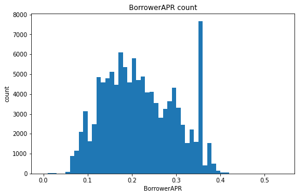

```python
#Plot histogram for BorrowerAPR
bins = np.arange(0, df.BorrowerAPR.max()+0.03, 0.01)
plt.figure(figsize=[8, 5])
plt.hist(data = df, x = 'BorrowerAPR', bins = bins);
plt.title('BorrowerAPR count')
plt.xlabel('BorrowerAPR')
plt.ylabel('count')
```

There is roughly a normal distribution with two exceptional high counts when BorrowerAPR are 0.35797% and 0.35643%. Only very few loans have APR greater than 0.42.

```python
# Check loans with APR greater than 0.43
df[df.BorrowerAPR>0.43]
```

|  | LoanOriginalAmount | BorrowerAPR | StatedMonthlyIncome | Term | ProsperRating (Alpha) | EmploymentStatus | Occupation | DelinquenciesLast7Years | AvailableBankcardCredit | ProsperScore |
| --- | --- | --- | --- | --- | --- | --- | --- | --- | --- | --- |
| 18326 | 3000 | 0.45857 | 10000.000000 | 36 | NaN | NaN | NaN | NaN | NaN | NaN |
| 22195 | 1789 | 0.46201 | 2916.666667 | 36 | NaN | NaN | NaN | NaN | NaN | NaN |
| 36018 | 1500 | 0.51229 | 2838.000000 | 36 | NaN | NaN | NaN | NaN | NaN | NaN |
| 56761 | 3000 | 0.50633 | 0.000000 | 36 | NaN | NaN | NaN | NaN | NaN | NaN |
| 82043 | 3000 | 0.48873 | 1583.333333 | 36 | NaN | NaN | NaN | NaN | NaN | NaN |
| 103973 | 2800 | 0.45857 | 3750.000000 | 36 | NaN | NaN | NaN | NaN | NaN | NaN |

The 6 borrowers with largest APR have small loan amount and don't have records of Prosper rating and employment status.

## **stated monthly income**

```python
df.StatedMonthlyIncome.max()
```

```
1750002.916667
```

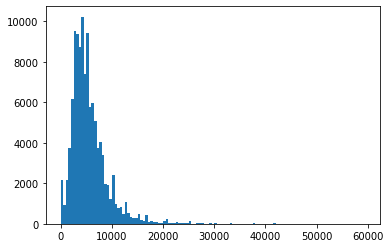

```python
# Distribution of stated monthly income
bins_smi = np.arange(0, 60000, 500)
plt.hist(data = df, x = 'StatedMonthlyIncome', bins=bins_smi);
```

The distribution of stated monthly income is highly right screwed, with most of stated monthly income less than 30k.

```python
# Get percent of borrowers whose stated monthly income greater than 30k
(df.StatedMonthlyIncome>30000).sum()/float(df.shape[0])
```

```
0.0028706369829341947
```

As less than 0.3 percent borrowers have stated monthly income greater than 30k, so these considered to be outliers should be removed.

```python
# remove loans with stated monthly income greater than 30k, which are outliers
df = df[df.StatedMonthlyIncome<=30000]
```

```python
(df.StatedMonthlyIncome>30000).sum()
```

```
0
```

## **Occupation**

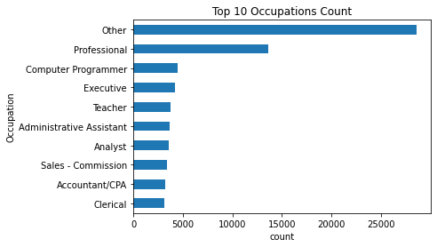

```python
# see the top 10 occupations of borrowers
df['Occupation'].value_counts()[9::-1].plot(kind='barh')
plt.title('Top 10 Occupations Count')
plt.xlabel('count')
plt.ylabel('Occupation')
plt.fontsize = 12
plt.figsize=(12,12)
```

## **Employment Status**

```python
df.EmploymentStatus.value_counts()
```

```
Employed         67135
Full-time        26297
Self-employed     6076
Not available     5334
Other             3805
Part-time         1088
Not employed       835
Retired            794
Name: EmploymentStatus, dtype: int64
```

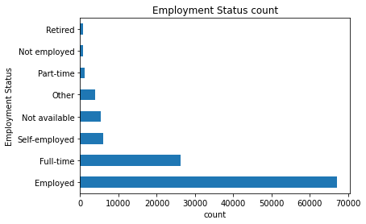

```python
# see the top 10 occupations of borrowers
df['EmploymentStatus'].value_counts().plot(kind='barh')
plt.title('Employment Status count')
plt.xlabel('count')
plt.ylabel('Employment Status')
plt.fontsize = 12
plt.figsize=(12,12)
```

Most of the borrowers are employed and then full-time emloyees.

# **Prosper rating Alpha**

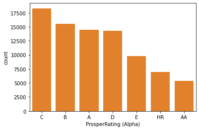

```python
sb.countplot(data = df, x = 'ProsperRating (Alpha)', color = sb.color_palette()[1],order = df['ProsperRating (Alpha)'].value_counts().index);
```

The ratings of most of the borrowers are A,B,C or D

## **Term**

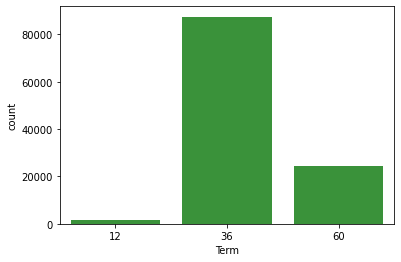

```python
sb.countplot(data = df, x = 'Term', color = sb.color_palette()[2]);
```

The length of most of the loans are 36 months.

## **Delinquencies from the last 7 years**

```python
df['DelinquenciesLast7Years'].value_counts()
```

```
0.0     76176
1.0      3958
3.0      3181
2.0      2872
4.0      2587
        ...
96.0        4
94.0        3
98.0        3
85.0        3
93.0        2
Name: DelinquenciesLast7Years, Length: 100, dtype: int64
```

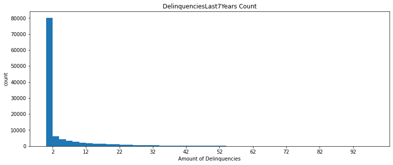

```python
# Histogram for Delinquencies records count from the Last 7Years.

plt.figure(figsize = [13, 5])
bins = np.arange(0, df['DelinquenciesLast7Years'].max(), 2)
plt.hist(data = df, x = 'DelinquenciesLast7Years', bins = bins)
plt.xticks(np.arange(2, 100+1, 10))
plt.title('DelinquenciesLast7Years Count')
plt.xlabel('Amount of Delinquencies')
plt.ylabel('count');
```

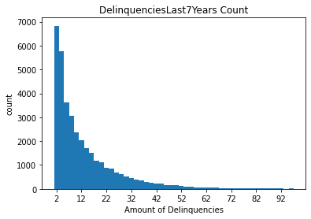

```python
bins = np.arange(1, df['DelinquenciesLast7Years'].max(), 2)
plt.hist(data = df, x = 'DelinquenciesLast7Years', bins = bins)
plt.xticks(np.arange(2, 100+1, 10))
plt.title('DelinquenciesLast7Years Count')
plt.xlabel('Amount of Delinquencies')
plt.ylabel('count');
```

Most borrowers has 0 Delinquencies records. So after excluding that value, we can better analyse the rest and see that counts decreases exponentially as the number of delinquencies increase.

### Discuss the distribution(s) of your variable(s) of interest. Were there any unusual points? Did you need to perform any transformations?

DelinquenciesLast7Years had a very large count for 0, so it had to be removed to see a better analysis of the rest of the values count.

### Of the features you investigated, were there any unusual distributions? Did you perform any operations on the data to tidy, adjust, or change the form of the data? If so, why did you do this?

StatedMonthyIncome and DelinquenciesLast7Years were highly right skewed while BorrowerAPR was normally distributed.

StatedMonthlyIncome greater than 30k were seen as outliers so they had to be removed.

# Bivariate Exploration

Now we will explore relations between different pairs of variables.

## **Heatmap**

It shows the corelation between every pair of numerical variables in the table.

This makes it easy to analyse how closely related any 2 variables are to eachother.

We can particularly see what most affects the borrower’s APR or interest rate?

```
<function matplotlib.pyplot.show>
```

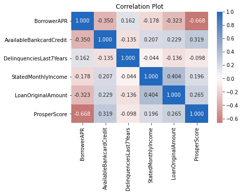

```python
num_vars = ['BorrowerAPR', 'AvailableBankcardCredit', 'DelinquenciesLast7Years', 'StatedMonthlyIncome','LoanOriginalAmount','ProsperScore']
# correlation plot
sb.heatmap(df[num_vars].corr(), annot = True, fmt = '.3f',
           cmap = 'vlag_r', center = 0)
plt.title('Correlation Plot')
plt.show
```

No pair of variables is highly corelated.

BorrowerAPR and ProsperScore are the most highly corelated (-0.668) but that too negatively.

DelinquenciesLast7Years and the StatedMonthlyIncome are least corelated.

BorrowerAPR is most effected by ProsperScore, followed by AvailableBankcardCredit.

## **PairGrid**

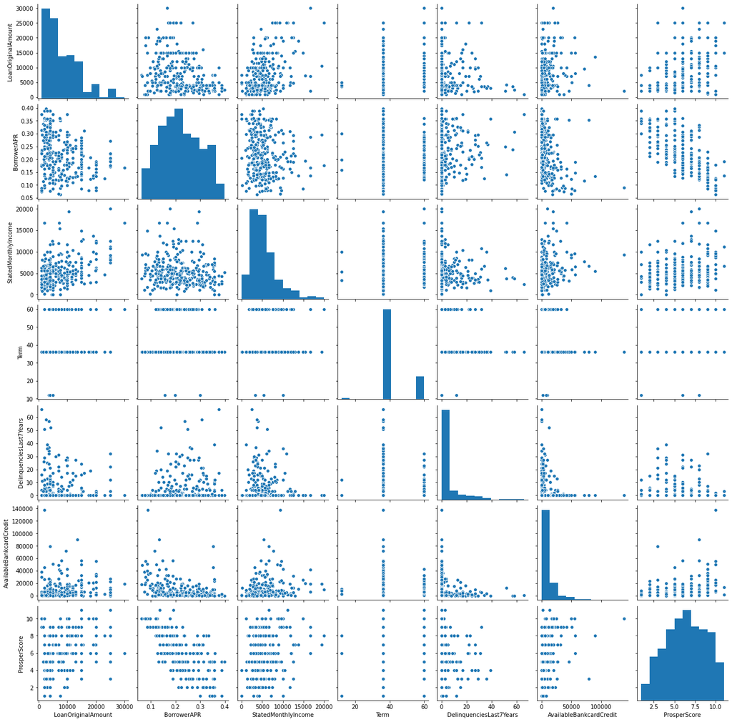

```python
# plot matrix: only 300 random loans are used to see the pattern more clearer
loan_sample = df.sample(300)
sb.pairplot(loan_sample)
```

The correlation coefficient of borrower APR and loan original amount is -0.323, the scatter plot also shows that these two variables are negatively correlated, that is the more the loan amount, the lower the APR.

The loan original amount is positively correlated with the stated monthly income (0.404),that is borrowers with more monthly income could loan more money.

BorrowerAPR and ProsperScore are negatively corelated (-0.668) as borrowers with lower score are more likely to pay higher APR.

ProsperScore seems to be more related to BorrowerAPR as compared to other variables.

## **Boxplots for categorical variables**

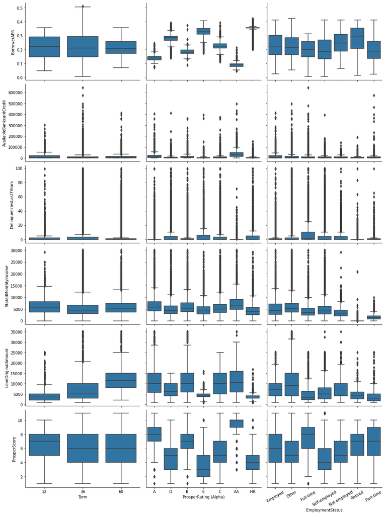

```python
# plot matrix of numeric features against categorical features.
cat_vars = ['Term', 'ProsperRating (Alpha)', 'EmploymentStatus']
def boxgrid(x, y, **kwargs):
    """ Quick hack for creating box plots with seaborn's PairGrid. """
    default_color = sb.color_palette()[0]
    sb.boxplot(x, y, color = default_color)

plt.figure(figsize = [10, 10])
g = sb.PairGrid(data = df, y_vars =  ['BorrowerAPR', 'AvailableBankcardCredit', 'DelinquenciesLast7Years', 'StatedMonthlyIncome','LoanOriginalAmount','ProsperScore'],
                x_vars = cat_vars, size = 3, aspect = 1.5)
g.map(boxgrid);
plt.xticks(rotation=30);
```

Loan amount is increased with the increase of loan term.

The borrower APR decreases with the better rating.

Borrowers with better rating have larger monthly income and loan amount.

## **Boxplots for BorrowerAPR vs. ProsperRating & ProsperScore.**

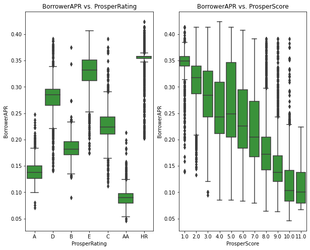

```python
# Boxplot for BorrowerAPR vs. ProsperRating & ProsperScore.
plt.figure(figsize = [15, 5])

plt.subplot(1, 2, 1)
sb.boxplot(data = df, x = 'ProsperRating (Alpha)', y = 'BorrowerAPR',color=sb.color_palette()[2])
plt.gcf().set_size_inches(10, 8)
plt.title('BorrowerAPR vs. ProsperRating')
plt.xlabel('ProsperRating')
plt.ylabel('BorrowerAPR')

plt.subplot(1, 2, 2)
sb.boxplot(data = df, x = 'ProsperScore', y = 'BorrowerAPR',color=sb.color_palette()[2])
plt.gcf().set_size_inches(10, 8)
plt.title('BorrowerAPR vs. ProsperScore')
plt.xlabel('ProsperScore')
plt.ylabel('BorrowerAPR');
```

For ProsperScore, there is a negative relationship with BorrowerAPR

## **Clustered Barcharts for ProsperRating, Terms and Employment Status**

Here we can see how these factors influence the loan status or define a trend overtime

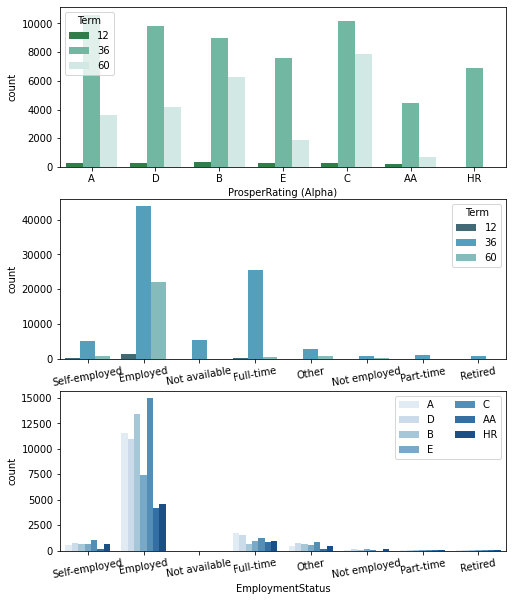

```python
plt.figure(figsize = [8, 10])

# subplot 1: Prosper rating vs term
plt.subplot(3, 1, 1)
sb.countplot(data = df, x = 'ProsperRating (Alpha)', hue = 'Term', palette = "BuGn_r")

# subplot 2: employment status vs. term
ax = plt.subplot(3, 1, 2)
sb.countplot(data = df, x = 'EmploymentStatus', hue = 'Term', palette = "GnBu_d")
plt.xticks(rotation=10)

# subplot 3: Prosper rating vs. employment status, use different color palette
ax = plt.subplot(3, 1, 3)
sb.countplot(data = df, x = 'EmploymentStatus', hue = 'ProsperRating (Alpha)', palette = "Blues")
ax.legend(loc = 1, ncol = 2); # re-arrange legend to remove overlapping
plt.xticks(rotation=10);
```

There is only 36 months loans for HR rating borrowers.

For each rating, there are most of 36 month loans.

There isn't enough data to show employment status variable of part-time, retired and not employed borrowers with term and Prosper rating variables.

### Talk about some of the relationships you observed in this part of the investigation. How did the feature(s) of interest vary with other features in the dataset?

The heatmaps for correlation and scatter matrix plots helped to see relationship of all possible variables related to BorrowerAPR. ProsperScore has the strongest relationship with BorrowerAPR but its negative correlated.

For all ProsperRating (Alpha), there was maximum count of 36 term loan period.

ProsperScore also negatively corelated with the BorrowerAPR.

Loan amount is increased with the increase of loan term.

The borrower APR decreases with the better rating.

Borrowers with better rating have larger monthly income and loan amount.

The loan original amount is positively correlated with the stated monthly income (0.404).

DelinquenciesLast7Years and the StatedMonthlyIncome are least corelated.

### Did you observe any interesting relationships between the other features (not the main feature(s) of interest)?

# Multivariate Exploration

Now we are going to explore relationships between more than 2 variables

## **BorrowerAPR vs AvailableBankcardCredit & ProsperScore**

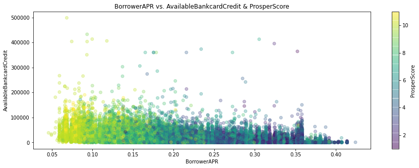

```python
plt.figure(figsize = [15, 5])
plt.scatter(data = df, x = 'BorrowerAPR', y = 'AvailableBankcardCredit', c ='ProsperScore', alpha = 0.3)
plt.colorbar(label = 'ProsperScore')
plt.title('BorrowerAPR vs. AvailableBankcardCredit & ProsperScore')
plt.xlabel('BorrowerAPR')
plt.ylabel('AvailableBankcardCredit');
```

## **Faceting for ProsperRating (Alpha) against BorrowerAPR and Loan amount**

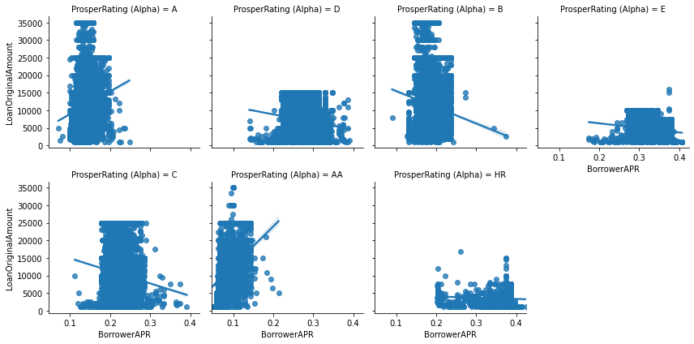

```python
plt.figure(figsize = [15, 8])
g = sb.FacetGrid(data = df, col = 'ProsperRating (Alpha)', col_wrap = 4, size = 3)
g.map(sb.regplot, 'BorrowerAPR', 'LoanOriginalAmount')
g.set_xlabels('BorrowerAPR')
g.set_ylabels('LoanOriginalAmount');
```

The loan amount increases with better rating.

The borrower APR decreases with better rating.

The relationship between borrower APR and loan amount turns from negative to slightly positive when the Prosper ratings get better(from HR to A) that is as people with better ratings tend to borrow more money, increasing APR and hence preventng them from borrowing more and vice versa.

## **Pointplot for ProsperRating(Alpha), Terms and Loan Amount**

Here we further see how the original amount of loans with respect to different prosper ratings and for each of the terms caused an effect on the loans.

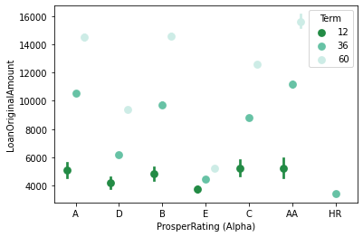

```python
sb.pointplot(data = df, x = 'ProsperRating (Alpha)', y = 'LoanOriginalAmount', hue = 'Term',
           palette = "BuGn_r", linestyles = '', dodge = 0.4);
```

### Talk about some of the relationships you observed in this part of the investigation. Were there features that strengthened each other in terms of looking at your feature(s) of interest?

The loan amount increases with better rating.

The borrower APR decreases with better rating.

The relationship between borrower APR and loan amount turns from negative to slightly positive when the Prosper ratings get better(from HR to A) that is as people with better ratings tend to borrow more money, increasing APR and hence preventng them from borrowing more and vice versa.